# 2021-02-12_22-13-24_Or179_Or177_overnight slides

```python
import numpy as np
import pandas as pd
import spikeextractors as se
import spiketoolkit as st
import spikewidgets as sw

import tqdm.notebook as tqdm
from scipy.signal import periodogram


import matplotlib.pyplot as plt
%matplotlib inline
%config InlineBackend.figure_format='retina'

from utils import *
```

Unpack data

```python
data_path = r'D:\D_Zs_Tetx\2021-02-12_22-13-24_Or179_Or177_overnight\Record Node 101\experiment1\recording1\continuous\Rhythm_FPGA-100.0\continuous.dat'

# Whole recording
recording = se.BinDatRecordingExtractor(
    data_path,
    30000,
    40, # Num channels
    dtype='int16',
)
```

```python
# First bird
Or179_recording = se.SubRecordingExtractor(
    recording,
    channel_ids=[0, 1, 2, 3, 4, 5, 6, 7, 8, 9, 10,11,12,13,14,15]
)

# Second bird
Or177_recording = se.SubRecordingExtractor(
    recording,
    channel_ids=[16, 17,18,19,20,21,22,23,24,25,26,27,28,29,30,31]
)
```

For `processing`, we need a way to extract sleep data.

### Let's find out what band SWRs are in

### This is probably not SWR because of accompanying noise on ch 13

```
(0.0021333333333333343, 29.8944, 10.0, 1000.0)
```

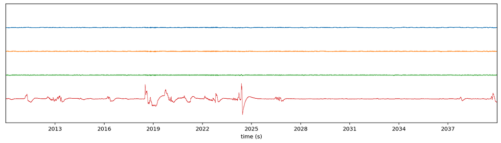

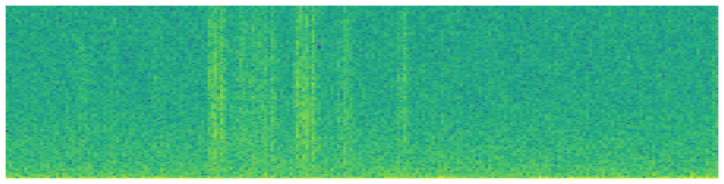

```python
fig=plt.figure(figsize=(16,4))
trange=[30*67, 30*68]
sw.plot_timeseries(Or179_recording, channel_ids=[0,2,4, 13], trange=trange, figure=fig)
for line in plt.gca().lines:
    line.set_linewidth(0.5)

fig=plt.figure(figsize=(16,4))
sw.plot_spectrogram(Or179_recording,channel=0, trange=trange,freqrange=[10,1000],nfft=256*2**4,figure=fig)
plt.gca().axis('off')
```

```
(0.002133333333333348, 15.861333333333333, 5.0, 250.0)
```

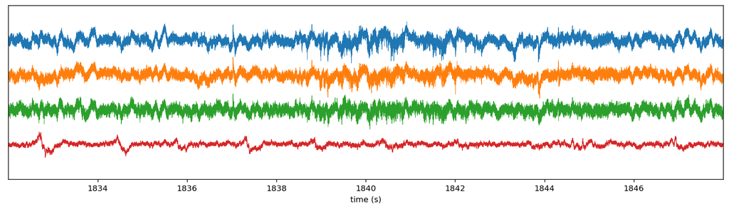

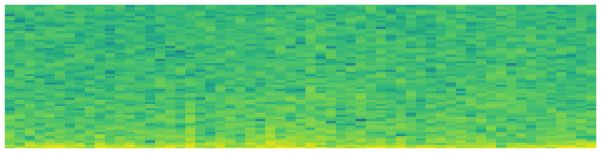

```python
trange=[1832,1848]
sw.plot_timeseries(Or179_recording, channel_ids=[0,2, 4,13], trange=trange, figure=plt.figure(figsize=(16,4)))
for line in plt.gca().lines:
    line.set_linewidth(0.5)

sw.plot_spectrogram(Or179_recording,channel=0, trange=trange,freqrange=[5,250],nfft=256*2**5,figure=plt.figure(figsize=(16,4)))
plt.gca().axis('off')
```

```python
Or179_recording.get_num_frames()/30000 * 2 * 100
```

```
9473223.68
```

```python
fig=plt.figure(figsize=[24,8])
sw.plot_timeseries(Or179_recording, channel_ids=[*range(9)],trange=[2225, 2660],figure=fig)
```

[output not shown]

Looks like channel 0 would work as well as any other. Now to extract periodograms for each second!

How many seconds are we iterating through?

```python
sr = Or179_recording.get_sampling_frequency()
num_sec = int(Or179_recording.get_num_frames() / sr) # rounds down

for second in tqdm.tqdm(range(num_sec-1)): # one less than total

    trace=Or179_recording.get_traces(channel_ids=[0],start_frame=second*sr, end_frame=(second+1)*sr)
    f, Pxx = periodogram(trace, sr)

    # Flatten
    Pxx = Pxx.flatten()

    # Get inds
    inds = (f > 0) & np.array(f<201)

    # Truncate arrays to 1-150 Hz
    f = f[inds]
    Pxx = Pxx[inds]

    # Sacrificing precision for space
    # Pxx = np.log10(Pxx).astype('float16')

    # Cast to smaller data type
    f = f.astype('uint8')

    # Add to csv file!
    df = pd.DataFrame(dict(t=second,f=f,logpower=np.log10(Pxx)))

    df.to_csv(
        r'C:\Users\danpo\Documents\LoisLFP\LoisLFP\data\2021-02-12_22-13-24_Or179_Or177_overnight\sleep.csv',
        mode='a',
        header=second==0 # only if it's the first second
    )
```

Let's put everything above into a script with Zsofi for automatically processing sleep data. Below, let's see what we GOT BABYY

```python
import pandas as pd
import holoviews as hv
import holoviews.operation.datashader

import panel as pn

hv.extension('bokeh')
from utils import *
```

```python
df = pd.read_csv(r'C:\Users\danpo\Documents\LoisLFP\LoisLFP\data\2021-02-12_22-13-24_Or179_Or177_overnight\sleep.csv')
del df['Unnamed: 0']

start = np.datetime64(get_recording_datetime(r'D:\D_Zs_Tetx\2021-02-12_22-13-24_Or179_Or177_overnight'))

# Make it in terms of datetime
# Really slow. How to make it faster?
df['t'] = df['t'].apply(lambda x: start+np.timedelta64(x, 's'))
```

```python
# Create time interval range slider
time_interval_slider = pn.widgets.RangeSlider(
    start=(df["t"].min()-start).seconds,
    end=(df["t"].max()-start).seconds,
    step=100,
    value=(
        (df["t"].min()-start).seconds,
        (df["t"].max()-start).seconds
    ),
    name="time (sec)",
)

frequency_slider = pn.widgets.IntSlider(
    start=df["f"].min(),
    end=df["f"].max(),
    step=1,
    value=30,
    name="frequency (Hz)",
)


# @pn.depends(frequency_slider.param.value)
@pn.depends(time_interval_slider.param.value_throttled, frequency_slider.param.value)
def plot_sleep(time_range, frequency):
    return hv.operation.datashader.datashade(
            hv.Curve(
                data=df.loc[
                    (df["f"]==frequency)
                    & (
                        (df["t"]>(start + np.timedelta64(time_range[0], 's')))
                        & (df["t"]<(start + np.timedelta64(time_range[1], 's')))
                    ),:],
                kdims=['t'],
                vdims=['logpower']
            ), aggregator='any',
        ).opts(frame_height=300, frame_width=1000, show_grid=True)

pn.Column(time_interval_slider, frequency_slider, plot_sleep)
```

[interactive chart not shown]

TODOs:

- Delineate night and day
- Spikes that show when singing occurred. Use that to find characteristic frequency(ies)
- Dreaming may be when low frequency is at low power, instead of trying to find when high frequencies are prominent
  - i.e., find places where high frequencies and low frequencies are anti-correlated
  - simpler version of this: plot difference of a high frequency (30?) and a low frequency (4?) and see if that is distinct and then see if frequencies coincide with "up" or "down" events
- with many csvs: look at smoothed frequency bands over multiple nights